# Omy_Klamath_Diversity_Temporal_Differentiation

Kevin Olsen

2024-11-18

```r
library(kableExtra)
library(gt)
library(gtsummary)
library(knitr)
library(khroma)
library(adegenet)
library(tidyverse)
library(magrittr)
library(poppr)
library(hierfstat)
library(car)
library(datawizard)
library(emmeans)
library(Rmisc)
```

Load quality filtered, location adjusted, and HWE/LD thinned markerset.

```r
load("C:/Users/olsenk2/OneDrive - Oregon State University/Desktop/Omy_klamath/Jan_2024_analyses/reproducible/Omykiss_Klamath_fullmarkerset_corrected_locations_Jan_2024_genos.R")
```

Revert the Omy-5 marker names to their original names (i.e., remove “Pearse” from the marker names). In the past, I’ve used base R to do this. Let’s try a tidyverse solution using the rename command from dplyr.

```r
full_markerset %<>%
  dplyr::rename(OmyR14589 = OmyR14589Pearse, OmyR19198 = OmyR19198Pearse, OmyR24370 = OmyR24370Pearse, OmyR33562 = OmyR33562Pearse, OmyR40252 = OmyR40252Pearse, OmyR40319 = OmyR40319Pearse)
```

Read in the metadata about markers. Filter the metadata to the markers that passed filtering.

```r
marker_mapping <- readxl::read_xlsx("C:/Users/olsenk2/OneDrive - Oregon State University/Desktop/Omykiss_Siletz_2023/Omy_GTseq_panel/final_mapping_results.xlsx", sheet = 1)

##filter mapping file to filtered markers in current panel##
marker_summary <- marker_mapping %>%
  mutate(marker = str_replace(marker, "Omy(\\d+)", "Chr\\1")) %>% # convert names to match
  filter(marker %in% colnames(full_markerset)) %>% # exclude filtered loci
  mutate(neutral = if_else(str_detect(`Presumed Type`, 'neutral|Neutral'), "neutral", "adaptive")) %>%
  mutate(run_timing = if_else(str_detect(`Presumed Type`, 'run|Run'), "run_timing", "non-run_timing")) %>%
  dplyr::select(marker, chr, start, 'Presumed Type', neutral, run_timing, Source)
```

Want to quantify temporal differentiation in the 13 sites with corresponding past and contemporary sampling events using the adaptive (n = 105 markers) and neutral (n = 193 markers) marker sets. Subset the adaptive markers.

```r
adaptive_marker_list<-subset(marker_summary, marker_summary$neutral == "adaptive")

##adaptive markerset with adjusted locations and sex marker##
adaptive_markerset<-full_markerset[, c(1:27, which(colnames(full_markerset) %in% adaptive_marker_list$marker))]    #include sampling metadata in columns 1:27##

##drop sex marker##
adaptive_markerset %<>%
  select(-one_of('OmyY1_2SEXY'))
```

subset the neutral markers.

```r
neutral_marker_list<-subset(marker_summary, marker_summary$neutral == "neutral")

##neutral markerset with adjusted locations##
neutral_markerset<-full_markerset[, c(1:27, which(colnames(full_markerset) %in% neutral_marker_list$marker))]  ##include sampling meta data in columns 1:27##
```

Currently, the 13 sites with corresponding past and contemporary sampling have the same location code. Create a new column to distninguish them.

```r
neutral_markerset %<>%
  mutate(loc_code_unique = case_when(location_code %in% c('METH') & year_sampled == "03" ~ 'METH_03',
                                     location_code %in% c('UJNY') & year_sampled == "00" ~ 'UJNY_00',
                                     location_code %in% c('BYPR') & year_sampled == "00" ~ 'BYPR_00',
                                     location_code %in% c('KENO') & year_sampled == "00" ~ 'KENO_00',
                                     location_code %in% c('SPCR') & year_sampled == "00" ~ 'SPCR_00',
                                     location_code %in% c('CHER') & year_sampled == "00" ~ 'CHER_00',
                                     location_code %in% c('SCSU') & year_sampled == "00" ~ 'SCSU_00',
                                     location_code %in% c('SFTC') & year_sampled == "00" ~ 'SFTC_00',
                                     location_code %in% c('ROKS') & year_sampled == "00" ~ 'ROKS_00',
                                     location_code %in% c('PASY') & year_sampled == "00" ~ 'PASY_00',
                                     location_code %in% c('LONG') & year_sampled == "00" ~ 'LONG_00',
                                     location_code %in% c('FIVE') & year_sampled == "00" ~ 'FIVE_00',
                                     location_code %in% c('NFSP') & year_sampled == "06" ~ 'NFSP_06',
                                     TRUE ~ as.character(location_code)
))
```

Put locations in same order as the map in Figure 1 and Table 1.

```r
##Set order of locations##

neutral_markerset %<>%
  mutate(site_number = case_when(loc_code_unique %in% c('HAYF') ~ '10',
                                 loc_code_unique %in% c('SALT') ~ '7',
                                 loc_code_unique %in% c('EFHF') ~ '8',
                                 loc_code_unique %in% c('POTA') ~ '9',
                                 loc_code_unique %in% c('RSCH') ~ '6',
                                 loc_code_unique %in% c('ELTP') ~ '5',
                                 loc_code_unique %in% c('JCNW') ~ '1',
                                 loc_code_unique %in% c('GROU') ~ '3',
                                 loc_code_unique %in% c('UDWD') ~ '4',
                                 loc_code_unique %in% c('MOSQ') ~ '2',
                                 loc_code_unique %in% c('HORS') ~ '18',
                                 loc_code_unique %in% c('RUSH') ~ '19',
                                 loc_code_unique %in% c('GARD') ~ '17',
                                 loc_code_unique %in% c('CLAR') ~ '15',
                                 loc_code_unique %in% c('PLUM') ~ '14',
                                 loc_code_unique %in% c('BKBR') ~ '13',
                                 loc_code_unique %in% c('METH_03') ~ '12',
                                 loc_code_unique %in% c('METH') ~ '12',
                                 loc_code_unique %in% c('KNOW') ~ '11',
                                 loc_code_unique %in% c('TAYL') ~ '16',
                                 loc_code_unique %in% c('SHAS') ~ '20',
                                 loc_code_unique %in% c('BOGS') ~ '21',
                                 loc_code_unique %in% c('LJNY') ~ '22',
                                 loc_code_unique %in% c('UJNY_00') ~ '23',
                                 loc_code_unique %in% c('UJNY') ~ '23',
                                 loc_code_unique %in% c('BEAV') ~ '24',
                                 loc_code_unique %in% c('COLD') ~ '25',
                                 loc_code_unique %in% c('SHOV') ~ '26',
                                 loc_code_unique %in% c('BYPR_00') ~ '28',
                                 loc_code_unique %in% c('BYPR') ~ '28',
                                 loc_code_unique %in% c('PEAR') ~ '27',
                                 loc_code_unique %in% c('KENO_00') ~ '29',
                                 loc_code_unique %in% c('KENO') ~ '29',
                                 loc_code_unique %in% c('SPCR_00') ~ '30',
                                 loc_code_unique %in% c('SPCR') ~ '30',
                                 loc_code_unique %in% c('UKLA') ~ '31',
                                 loc_code_unique %in% c('DENN') ~ '32',
                                 loc_code_unique %in% c('MOSS') ~ '33',
                                 loc_code_unique %in% c('CHER_00') ~ '34',
                                 loc_code_unique %in% c('CHER') ~ '34',
                                 loc_code_unique %in% c('SEVN') ~ '35',
                                 loc_code_unique %in% c('AGNC') ~ '36',
                                 loc_code_unique %in% c('TECH') ~ '37',
                                 loc_code_unique %in% c('FORT') ~ '38',
                                 loc_code_unique %in% c('WOOD') ~ '39',
                                 loc_code_unique %in% c('ANNI') ~ '40',
                                 loc_code_unique %in% c('PINE') ~ '41',
                                 loc_code_unique %in% c('SCFA') ~ '42',
                                 loc_code_unique %in% c('SCSU_00') ~ '42',
                                 loc_code_unique %in% c('SCSU') ~ '42',
                                 loc_code_unique %in% c('SUNY') ~ '43',
                                 loc_code_unique %in% c('KNAP') ~ '44',
                                 loc_code_unique %in% c('UWIL') ~ '45',
                                 loc_code_unique %in% c('SFTC_00') ~ '48',
                                 loc_code_unique %in% c('SFTC') ~ '48',
                                 loc_code_unique %in% c('ROKS_00') ~ '49',
                                 loc_code_unique %in% c('ROKS') ~ '49',
                                 loc_code_unique %in% c('BTTY') ~ '47',
                                 loc_code_unique %in% c('PASY_00') ~ '51',
                                 loc_code_unique %in% c('PASY') ~ '51',
                                 loc_code_unique %in% c('LONG_00') ~ '50',
                                 loc_code_unique %in% c('LONG') ~ '50',
                                 loc_code_unique %in% c('FIVE_00') ~ '52',
                                 loc_code_unique %in% c('FIVE') ~ '52',
                                 loc_code_unique %in% c('MRYL') ~ '53',
                                 loc_code_unique %in% c('NFSP_06') ~ '54',
                                 loc_code_unique %in% c('NFSP') ~ '54',
                                 loc_code_unique %in% c('PASP') ~ '55',
                                 loc_code_unique %in% c('WHIT') ~ '56',
                                 loc_code_unique %in% c('SFSP') ~ '57',
                                 loc_code_unique %in% c('KAMK') ~ '46',
                                 loc_code_unique %in% c('CHEW') ~ '58',
                                 loc_code_unique %in% c('FOST') ~ '59',
                                 loc_code_unique %in% c('OAKH') ~ '60'
  ))

neutral_markerset %<>%
  relocate(loc_code_unique, site_number)

##put in order##
neutral_markerset$site_number<-as.numeric(neutral_markerset$site_number)

neutral_markerset<-neutral_markerset[order(neutral_markerset$site_number), ]

##Set order##
neutral_markerset$site_number<-factor(neutral_markerset$site_number, levels = unique(neutral_markerset$site_number))
```

Convert neutral dataframe to genind object and then to genalex object for use in the R package poppr.

```r
##Replace dots in column names with underscores
colnames(neutral_markerset) <- gsub("\\.", "_", colnames(neutral_markerset))

neutral_matrix <- as.matrix(neutral_markerset[,c(30:(ncol(neutral_markerset)))])  ##create a matrix of just the genotype columns 30:222###
row.names(neutral_matrix) <- neutral_markerset$sample_simple                           ##add sample names as rownames to the matrix
neutral_genind<- df2genind(neutral_matrix, sep = "" , ploidy = 2, NA.char = "0")        ##convert to genind object
neutral_genind@pop <- as.factor(neutral_markerset$loc_code_unique)                       ##set location code as identifying factor

genind2genalex(neutral_genind, file = "C:/Users/olsenk2/OneDrive - Oregon State University/Desktop/Omy_klamath/Jan_2024_analyses/reproducible/Omykiss_Klamath_Neutral_location_adjusted_genalex_Jan_2024.csv")
```

```
## Extracting the table ... Writing the table to C:/Users/olsenk2/OneDrive - Oregon State University/Desktop/Omy_klamath/Jan_2024_analyses/reproducible/Omykiss_Klamath_Neutral_location_adjusted_genalex_Jan_2024.csv ... Done.
```

```
## [1] "C:/Users/olsenk2/OneDrive - Oregon State University/Desktop/Omy_klamath/Jan_2024_analyses/reproducible/Omykiss_Klamath_Neutral_location_adjusted_genalex_Jan_2024.csv"
```

Read in the neutral markerset genalex object and calculate Nei’s genetic diversity for the 2,466 samples collected in 74 sampling events from 60 unique locations (Table 1 and Table 2).

```r
##read in neutral markerset genalex object##
neutral_genalex<-read.genalex("C:/Users/olsenk2/OneDrive - Oregon State University/Desktop/Omy_klamath/Jan_2024_analyses/reproducible/Omykiss_Klamath_Neutral_location_adjusted_genalex_Jan_2024.csv")

gen_stats<-poppr(neutral_genalex)

kable(gen_stats[, c(1:2, 10)] )
```

| Pop | N | Hexp |
| --- | --- | --- |
| JCNW | 54 | 0.2845223 |
| MOSQ | 14 | 0.2770908 |
| GROU | 13 | 0.2672974 |
| UDWD | 11 | 0.2608940 |
| ELTP | 26 | 0.2958126 |
| RSCH | 12 | 0.2812941 |
| SALT | 15 | 0.2693116 |
| EFHF | 12 | 0.2868207 |
| POTA | 13 | 0.2896039 |
| HAYF | 16 | 0.2493112 |
| KNOW | 16 | 0.2698813 |
| METH_03 | 20 | 0.2649836 |
| METH | 21 | 0.2724725 |
| BKBR | 20 | 0.2716945 |
| PLUM | 15 | 0.2750463 |
| CLAR | 14 | 0.2664892 |
| TAYL | 15 | 0.2673075 |
| GARD | 24 | 0.2667674 |
| HORS | 19 | 0.2637804 |
| RUSH | 20 | 0.2650980 |
| SHAS | 18 | 0.2622132 |
| BOGS | 17 | 0.2709180 |
| LJNY | 45 | 0.2580332 |
| UJNY | 21 | 0.2703376 |
| UJNY_00 | 44 | 0.2675636 |
| BEAV | 38 | 0.1965590 |
| COLD | 47 | 0.2024725 |
| SHOV | 28 | 0.2506532 |
| PEAR | 55 | 0.2588317 |
| BYPR | 28 | 0.2476758 |
| BYPR_00 | 38 | 0.2479193 |
| KENO | 78 | 0.2405733 |
| KENO_00 | 12 | 0.2406339 |
| SPCR | 67 | 0.2349118 |
| SPCR_00 | 69 | 0.2341928 |
| UKLA | 27 | 0.1377727 |
| DENN | 24 | 0.2137119 |
| MOSS | 27 | 0.1952540 |
| CHER | 29 | 0.2194339 |
| CHER_00 | 28 | 0.2382145 |
| SEVN | 54 | 0.1257602 |
| AGNC | 75 | 0.1630368 |
| TECH | 44 | 0.1387267 |
| FORT | 78 | 0.1139914 |
| WOOD | 75 | 0.1045225 |
| ANNI | 49 | 0.1092370 |
| PINE | 101 | 0.1067415 |
| SCSU_00 | 15 | 0.1152309 |
| SCSU | 77 | 0.1274054 |
| SCFA | 49 | 0.0933343 |
| SUNY | 19 | 0.1330947 |
| KNAP | 27 | 0.1371971 |
| UWIL | 44 | 0.2417840 |
| KAMK | 10 | 0.1386454 |
| BTTY | 64 | 0.1313034 |
| SFTC | 17 | 0.1896401 |
| SFTC_00 | 25 | 0.2404295 |
| ROKS | 17 | 0.0997574 |
| ROKS_00 | 19 | 0.1192856 |
| LONG | 13 | 0.2449803 |
| LONG_00 | 38 | 0.2464165 |
| PASY_00 | 31 | 0.2503339 |
| PASY | 22 | 0.2737609 |
| FIVE_00 | 18 | 0.2105682 |
| FIVE | 60 | 0.2178602 |
| MRYL | 28 | 0.2511199 |
| NFSP | 41 | 0.2576776 |
| NFSP_06 | 28 | 0.2610511 |
| PASP | 25 | 0.1938290 |
| WHIT | 43 | 0.2983307 |
| SFSP | 21 | 0.2708693 |
| CHEW | 38 | 0.2568970 |
| FOST | 13 | 0.0741896 |
| OAKH | 78 | 0.2790181 |
| Total | 2466 | 0.2753208 |

Quantify temporal differentiation in the 13 locations with past and contemporary sampling using the Nei’s FST in the R package hierfstat. Sample markers with replacement (i.e., bootstrap) 1,000 times to estimate the 95% confidence interval for each pairwise measure of FST (Table 3). Note, this will take a few minutes to run. First with the neutral marker set.

```r
##Subset past and contemporary sampling
temporal<-popsub(neutral_genalex, c("METH_03", "METH", "UJNY_00", "UJNY", "BYPR_00", "BYPR", "KENO_00", "KENO", "SPCR_00", "SPCR",
                                    "CHER_00", "CHER", "SCSU_00", "SCSU", "SFTC_00", "SFTC", "ROKS_00", "ROKS", "PASY_00", "PASY",
                                    "LONG_00", "LONG", "FIVE_00", "FIVE", "NFSP_06", "NFSP"))

##Quantify genetic distance (i.e., FST)
temporal_fst<-pairwise.neifst(temporal)

##Sample with replacement (bootstrap) markers 1,000 times to estimate lower and upper 95% confidence limits
temporal_boot<-boot.ppfst(temporal, nboot = 1000, quant = c(0.025, 0.975), diploid = TRUE)

##Output of FST command is a pairwise matrix. Convert to 3 column dataframe with paired sampling names and FST as columns
xy<-t(combn(colnames(temporal_fst), 2))                                              ##Generate all pairwise combinations of sampling events with the base R command combn. Then transpose.
temporal_fst<-data.frame(xy, FST = temporal_fst[xy])                                ##Add the FST values

##Convert pairwise matrix of lower confidence limits to 3 column dataframe
xy_low<-t(combn(colnames(temporal_boot$ll), 2))                                    ##Generate all pairwise combinations of sampling events with the base R command combn. Then transpose.
boot_low<-data.frame(xy_low, Lower = temporal_boot$ll[xy_low])                    ##Add lower confidence limits

##Convert pairiwse matrix of upper confidence limits to 3 column dataframe
xy_upper<-t(combn(colnames(temporal_boot$ul), 2))
boot_upper<-data.frame(xy_upper, Upper = temporal_boot$ul[xy_upper])             ## Add upper confidence limits

##Add lower and upper confidence limits to dataframe with FST estimates using left_join
temporal_fst %<>%
  left_join(select(boot_low, X1, X2, Lower), by = join_by(X1, X2))

temporal_fst %<>%
  left_join(select(boot_upper, X1, X2, Upper), by = join_by(X1, X2)) %>%   ##Add upper confidence limit
  mutate(confidence_interval = (Upper - Lower) / 2) %>%                          ##Calculate confidence interval by substracting lower limit from upper limit and divide by 2
  mutate(past_code = substr(X1, 1, 4)) %>%                               ##Get basename of past collection code
  mutate(contemp_code = substr(X2, 1, 4)) %>%                           ##Get basename of contemporary collection code
  filter(past_code == contemp_code) %>%                                 ##filter to rows with matching basename collection codes (e.g., Meth in 03 and Meth contemporary)
  dplyr::rename(sample_1 = X1, sample_2 = X2)

kable(temporal_fst[, c(1:3, 6)])
```

| sample_1 | sample_2 | FST | confidence_interval |
| --- | --- | --- | --- |
| METH_03 | METH | 0.0196 | 0.0097149 |
| UJNY | UJNY_00 | 0.0068 | 0.0060453 |
| BYPR | BYPR_00 | -0.0010 | 0.0036348 |
| KENO | KENO_00 | 0.0008 | 0.0061035 |
| SPCR | SPCR_00 | 0.0009 | 0.0016716 |
| CHER | CHER_00 | 0.0126 | 0.0068376 |
| SCSU_00 | SCSU | 0.0061 | 0.0062748 |
| SFTC | SFTC_00 | 0.0729 | 0.0199565 |
| ROKS | ROKS_00 | 0.0835 | 0.0348405 |
| LONG | LONG_00 | 0.0032 | 0.0055751 |
| PASY_00 | PASY | 0.0317 | 0.0112851 |
| FIVE_00 | FIVE | 0.0023 | 0.0041349 |
| NFSP | NFSP_06 | 0.0111 | 0.0070771 |

Prepare adaptive marker set.

```r
##Distinguish past and contemporary collections##
adaptive_markerset %<>%
  mutate(loc_code_unique = case_when(location_code %in% c('METH') & year_sampled == "03" ~ 'METH_03',
                                     location_code %in% c('UJNY') & year_sampled == "00" ~ 'UJNY_00',
                                     location_code %in% c('BYPR') & year_sampled == "00" ~ 'BYPR_00',
                                     location_code %in% c('KENO') & year_sampled == "00" ~ 'KENO_00',
                                     location_code %in% c('SPCR') & year_sampled == "00" ~ 'SPCR_00',
                                     location_code %in% c('CHER') & year_sampled == "00" ~ 'CHER_00',
                                     location_code %in% c('SCSU') & year_sampled == "00" ~ 'SCSU_00',
                                     location_code %in% c('SFTC') & year_sampled == "00" ~ 'SFTC_00',
                                     location_code %in% c('ROKS') & year_sampled == "00" ~ 'ROKS_00',
                                     location_code %in% c('PASY') & year_sampled == "00" ~ 'PASY_00',
                                     location_code %in% c('LONG') & year_sampled == "00" ~ 'LONG_00',
                                     location_code %in% c('FIVE') & year_sampled == "00" ~ 'FIVE_00',
                                     location_code %in% c('NFSP') & year_sampled == "06" ~ 'NFSP_06',
                                     TRUE ~ as.character(location_code)
  ))
##Put locations in same order as the map in Figure 1 and Table 1.
##Set order of locations##
adaptive_markerset %<>%
  mutate(site_number = case_when(loc_code_unique %in% c('HAYF') ~ '10',
                                 loc_code_unique %in% c('SALT') ~ '7',
                                 loc_code_unique %in% c('EFHF') ~ '8',
                                 loc_code_unique %in% c('POTA') ~ '9',
                                 loc_code_unique %in% c('RSCH') ~ '6',
                                 loc_code_unique %in% c('ELTP') ~ '5',
                                 loc_code_unique %in% c('JCNW') ~ '1',
                                 loc_code_unique %in% c('GROU') ~ '3',
                                 loc_code_unique %in% c('UDWD') ~ '4',
                                 loc_code_unique %in% c('MOSQ') ~ '2',
                                 loc_code_unique %in% c('HORS') ~ '18',
                                 loc_code_unique %in% c('RUSH') ~ '19',
                                 loc_code_unique %in% c('GARD') ~ '17',
                                 loc_code_unique %in% c('CLAR') ~ '15',
                                 loc_code_unique %in% c('PLUM') ~ '14',
                                 loc_code_unique %in% c('BKBR') ~ '13',
                                 loc_code_unique %in% c('METH_03') ~ '12',
                                 loc_code_unique %in% c('METH') ~ '12',
                                 loc_code_unique %in% c('KNOW') ~ '11',
                                 loc_code_unique %in% c('TAYL') ~ '16',
                                 loc_code_unique %in% c('SHAS') ~ '20',
                                 loc_code_unique %in% c('BOGS') ~ '21',
                                 loc_code_unique %in% c('LJNY') ~ '22',
                                 loc_code_unique %in% c('UJNY_00') ~ '23',
                                 loc_code_unique %in% c('UJNY') ~ '23',
                                 loc_code_unique %in% c('BEAV') ~ '24',
                                 loc_code_unique %in% c('COLD') ~ '25',
                                 loc_code_unique %in% c('SHOV') ~ '26',
                                 loc_code_unique %in% c('BYPR_00') ~ '28',
                                 loc_code_unique %in% c('BYPR') ~ '28',
                                 loc_code_unique %in% c('PEAR') ~ '27',
                                 loc_code_unique %in% c('KENO_00') ~ '29',
                                 loc_code_unique %in% c('KENO') ~ '29',
                                 loc_code_unique %in% c('SPCR_00') ~ '30',
                                 loc_code_unique %in% c('SPCR') ~ '30',
                                 loc_code_unique %in% c('UKLA') ~ '31',
                                 loc_code_unique %in% c('DENN') ~ '32',
                                 loc_code_unique %in% c('MOSS') ~ '33',
                                 loc_code_unique %in% c('CHER_00') ~ '34',
                                 loc_code_unique %in% c('CHER') ~ '34',
                                 loc_code_unique %in% c('SEVN') ~ '35',
                                 loc_code_unique %in% c('AGNC') ~ '36',
                                 loc_code_unique %in% c('TECH') ~ '37',
                                 loc_code_unique %in% c('FORT') ~ '38',
                                 loc_code_unique %in% c('WOOD') ~ '39',
                                 loc_code_unique %in% c('ANNI') ~ '40',
                                 loc_code_unique %in% c('PINE') ~ '41',
                                 loc_code_unique %in% c('SCFA') ~ '42',
                                 loc_code_unique %in% c('SCSU_00') ~ '42',
                                 loc_code_unique %in% c('SCSU') ~ '42',
                                 loc_code_unique %in% c('SUNY') ~ '43',
                                 loc_code_unique %in% c('KNAP') ~ '44',
                                 loc_code_unique %in% c('UWIL') ~ '45',
                                 loc_code_unique %in% c('SFTC_00') ~ '48',
                                 loc_code_unique %in% c('SFTC') ~ '48',
                                 loc_code_unique %in% c('ROKS_00') ~ '49',
                                 loc_code_unique %in% c('ROKS') ~ '49',
                                 loc_code_unique %in% c('BTTY') ~ '47',
                                 loc_code_unique %in% c('PASY_00') ~ '51',
                                 loc_code_unique %in% c('PASY') ~ '51',
                                 loc_code_unique %in% c('LONG_00') ~ '50',
                                 loc_code_unique %in% c('LONG') ~ '50',
                                 loc_code_unique %in% c('FIVE_00') ~ '52',
                                 loc_code_unique %in% c('FIVE') ~ '52',
                                 loc_code_unique %in% c('MRYL') ~ '53',
                                 loc_code_unique %in% c('NFSP_06') ~ '54',
                                 loc_code_unique %in% c('NFSP') ~ '54',
                                 loc_code_unique %in% c('PASP') ~ '55',
                                 loc_code_unique %in% c('WHIT') ~ '56',
                                 loc_code_unique %in% c('SFSP') ~ '57',
                                 loc_code_unique %in% c('KAMK') ~ '46',
                                 loc_code_unique %in% c('CHEW') ~ '58',
                                 loc_code_unique %in% c('FOST') ~ '59',
                                 loc_code_unique %in% c('OAKH') ~ '60'
  ))

adaptive_markerset %<>%
  relocate(loc_code_unique, site_number)

##put in order##
adaptive_markerset$site_number<-as.numeric(adaptive_markerset$site_number)
adaptive_markerset<-adaptive_markerset[order(adaptive_markerset$site_number), ]

##Set order##
adaptive_markerset$site_number<-factor(adaptive_markerset$site_number, levels = unique(adaptive_markerset$site_number))
```

Convert adaptive dataframe to genind object and then to genalex object for use in the R package poppr.

```r
##Replace dots in column names with underscores
colnames(adaptive_markerset) <- gsub("\\.", "_", colnames(adaptive_markerset))

adaptive_matrix <- as.matrix(adaptive_markerset[,c(30:(ncol(adaptive_markerset)))])  ##create a matrix of just the genotype columns 30:134###
row.names(adaptive_matrix) <- adaptive_markerset$sample_simple                           ##add sample names as rownames to the matrix
adaptive_genind<- df2genind(adaptive_matrix, sep = "" , ploidy = 2, NA.char = "0")        ##convert to genind object
adaptive_genind@pop <- as.factor(adaptive_markerset$loc_code_unique)                       ##set location code as identifying factor

genind2genalex(adaptive_genind, file = "C:/Users/olsenk2/OneDrive - Oregon State University/Desktop/Omy_klamath/Jan_2024_analyses/reproducible/Omykiss_Klamath_Adaptive_location_adjusted_genalex_Jan_2024.csv")
```

```
## Extracting the table ... Writing the table to C:/Users/olsenk2/OneDrive - Oregon State University/Desktop/Omy_klamath/Jan_2024_analyses/reproducible/Omykiss_Klamath_Adaptive_location_adjusted_genalex_Jan_2024.csv ... Done.
```

```
## [1] "C:/Users/olsenk2/OneDrive - Oregon State University/Desktop/Omy_klamath/Jan_2024_analyses/reproducible/Omykiss_Klamath_Adaptive_location_adjusted_genalex_Jan_2024.csv"
```

Quantify temporal differentiation with adaptive marker set (Table 3).

```r
##read in adaptive markerset genalex object##
adaptive_genalex<-read.genalex("C:/Users/olsenk2/OneDrive - Oregon State University/Desktop/Omy_klamath/Jan_2024_analyses/reproducible/Omykiss_Klamath_Adaptive_location_adjusted_genalex_Jan_2024.csv")

##Subset past and contemporary sampling
temporal<-popsub(adaptive_genalex, c("METH_03", "METH", "UJNY_00", "UJNY", "BYPR_00", "BYPR", "KENO_00", "KENO", "SPCR_00", "SPCR",
                                    "CHER_00", "CHER", "SCSU_00", "SCSU", "SFTC_00", "SFTC", "ROKS_00", "ROKS", "PASY_00", "PASY",
                                    "LONG_00", "LONG", "FIVE_00", "FIVE", "NFSP_06", "NFSP"))

##Quantify genetic distance (i.e., FST)
temporal_fst<-pairwise.neifst(temporal)

##Sample with replacement (bootstrap) markers 1,000 times to estimate lower and upper 95% confidence limits
temporal_boot<-boot.ppfst(temporal, nboot = 1000, quant = c(0.025, 0.975), diploid = TRUE)

##Output of FST command is a pairwise matrix. Convert to 3 column dataframe with paired sampling names and FST as columns
xy<-t(combn(colnames(temporal_fst), 2))                                              ##Generate all pairwise combinations of sampling events with the base R command combn. Then transpose.
temporal_fst<-data.frame(xy, FST = temporal_fst[xy])                                ##Add the FST values

##Convert pairwise matrix of lower confidence limits to 3 column dataframe
xy_low<-t(combn(colnames(temporal_boot$ll), 2))                                    ##Generate all pairwise combinations of sampling events with the base R command combn. Then transpose.
boot_low<-data.frame(xy_low, Lower = temporal_boot$ll[xy_low])                    ##Add lower confidence limits

##Convert pairiwse matrix of upper confidence limits to 3 column dataframe
xy_upper<-t(combn(colnames(temporal_boot$ul), 2))
boot_upper<-data.frame(xy_upper, Upper = temporal_boot$ul[xy_upper])             ## Add upper confidence limits

##Add lower and upper confidence limits to dataframe with FST estimates using left_join
temporal_fst %<>%
  left_join(select(boot_low, X1, X2, Lower), by = join_by(X1, X2))

temporal_fst %<>%
  left_join(select(boot_upper, X1, X2, Upper), by = join_by(X1, X2)) %>%   ##Add upper confidence limit
  mutate(confidence_interval = (Upper - Lower) / 2) %>%                          ##Calculate confidence interval by substracting lower limit from upper limit and divide by 2
  mutate(past_code = substr(X1, 1, 4)) %>%                               ##Get basename of past collection code
  mutate(contemp_code = substr(X2, 1, 4)) %>%                           ##Get basename of contemporary collection code
  filter(past_code == contemp_code) %>%                                 ##filter to rows with matching basename collection codes (e.g., Meth in 03 and Meth contemporary)
  dplyr::rename(sample_1 = X1, sample_2 = X2)

kable(temporal_fst[, c(1:3, 6)])
```

| sample_1 | sample_2 | FST | confidence_interval |
| --- | --- | --- | --- |
| METH_03 | METH | 0.0581 | 0.0373675 |
| UJNY | UJNY_00 | 0.0104 | 0.0111842 |
| BYPR | BYPR_00 | 0.0117 | 0.0092490 |
| KENO | KENO_00 | 0.0007 | 0.0064217 |
| SPCR | SPCR_00 | 0.0013 | 0.0039033 |
| CHER | CHER_00 | 0.0250 | 0.0128048 |
| SCSU_00 | SCSU | 0.0104 | 0.0182083 |
| SFTC | SFTC_00 | 0.0707 | 0.0304423 |
| ROKS | ROKS_00 | 0.1043 | 0.0636530 |
| LONG | LONG_00 | 0.0183 | 0.0133125 |
| PASY_00 | PASY | 0.0263 | 0.0145401 |
| FIVE_00 | FIVE | 0.0014 | 0.0049271 |
| NFSP | NFSP_06 | 0.0068 | 0.0067153 |

Evaluate differences in genetic diversity (i.e., expected heterozygosity) among Life-history types (Supplemental Figure 1). Generate a dataframe of expected heterozygosity values for each sampling event from the poppr output.

```r
genetic_diversity<-gen_stats %>%
  select(Pop, N, Hexp) %>%
  filter(! Pop == "Total")          ##drop the total in the last row


##Add the watershed and life-history designations for each sampling location
genetic_diversity %<>%
  left_join(select(neutral_markerset, loc_code_unique, Watershed), by = c("Pop" = "loc_code_unique"), multiple = "first") %>%
  mutate(life_history = case_when(Watershed %in% c('Trinity River', 'Salmon River', 'Lower Klamath River') ~ 'A',
                                  Pop %in% c('LJNY', 'UJNY', 'UJNY_00', 'BEAV', 'COLD', 'MOSS', 'CHER',
                                             'CHER_00', 'UWIL', 'SFTC', 'SFTC_00', 'ROKS', 'ROKS_00',
                                             'PASY_00', 'PASY', 'FIVE_00', 'FIVE', 'MRYL', 'PASP', 'WHIT', 'FOST', 'OAKH') ~ 'R',
                                  Watershed %in% c('Upper Klamath Lake', 'Wood River') ~ 'ADF',
                                  Pop %in% c('SHOV', 'DENN', 'SEVN', 'PINE', 'SCSU_00', 'SCSU', 'SCFA', 'SUNY', 'KNAP', 'KAMK', 'BTTY') ~ 'ADF',
                                  Pop %in% c('PEAR', 'BYPR', 'BYPR_00', 'KENO', 'KENO_00', 'SPCR', 'SPCR_00', 'LONG', 'LONG_00',
                                             'NFSP', 'NFSP_06', 'SFSP', 'CHEW') ~ 'FLU'))
```

Attempted multiple transformations but couldn’t transform expected heterozygosity into a normal distribution. Rank transform instead with R package datawizard.

```r
genetic_diversity %<>%
  mutate(ranked = ranktransform(Hexp))

kable(genetic_diversity)
```

| Pop | N | Hexp | Watershed | life_history | ranked |
| --- | --- | --- | --- | --- | --- |
| JCNW | 54 | 0.2845223 | Trinity River | A | 70 |
| MOSQ | 14 | 0.2770908 | Trinity River | A | 67 |
| GROU | 13 | 0.2672974 | Trinity River | A | 55 |
| UDWD | 11 | 0.2608940 | Trinity River | A | 47 |
| ELTP | 26 | 0.2958126 | Trinity River | A | 73 |
| RSCH | 12 | 0.2812941 | Trinity River | A | 69 |
| SALT | 15 | 0.2693116 | Trinity River | A | 58 |
| EFHF | 12 | 0.2868207 | Trinity River | A | 71 |
| POTA | 13 | 0.2896039 | Trinity River | A | 72 |
| HAYF | 16 | 0.2493112 | Trinity River | A | 39 |
| KNOW | 16 | 0.2698813 | Salmon River | A | 59 |
| METH_03 | 20 | 0.2649836 | Salmon River | A | 51 |
| METH | 21 | 0.2724725 | Salmon River | A | 64 |
| BKBR | 20 | 0.2716945 | Salmon River | A | 63 |
| PLUM | 15 | 0.2750463 | Salmon River | A | 66 |
| CLAR | 14 | 0.2664892 | Salmon River | A | 53 |
| TAYL | 15 | 0.2673075 | Salmon River | A | 56 |
| GARD | 24 | 0.2667674 | Salmon River | A | 54 |
| HORS | 19 | 0.2637804 | Salmon River | A | 50 |
| RUSH | 20 | 0.2650980 | Salmon River | A | 52 |
| SHAS | 18 | 0.2622132 | Lower Klamath River | A | 49 |
| BOGS | 17 | 0.2709180 | Lower Klamath River | A | 62 |
| LJNY | 45 | 0.2580332 | Klamath River | R | 45 |
| UJNY | 21 | 0.2703376 | Klamath River | R | 60 |
| UJNY_00 | 44 | 0.2675636 | Klamath River | R | 57 |
| BEAV | 38 | 0.1965590 | Klamath River | R | 22 |
| COLD | 47 | 0.2024725 | Klamath River | R | 23 |
| SHOV | 28 | 0.2506532 | Klamath River | ADF | 41 |
| PEAR | 55 | 0.2588317 | Klamath River | FLU | 46 |
| BYPR | 28 | 0.2476758 | Klamath River | FLU | 37 |
| BYPR_00 | 38 | 0.2479193 | Klamath River | FLU | 38 |
| KENO | 78 | 0.2405733 | Klamath River | FLU | 32 |
| KENO_00 | 12 | 0.2406339 | Klamath River | FLU | 33 |
| SPCR | 67 | 0.2349118 | Klamath River | FLU | 29 |
| SPCR_00 | 69 | 0.2341928 | Klamath River | FLU | 28 |
| UKLA | 27 | 0.1377727 | Upper Klamath Lake | ADF | 15 |
| DENN | 24 | 0.2137119 | Klamath Cascade Tributaries | ADF | 25 |
| MOSS | 27 | 0.1952540 | Klamath Cascade Tributaries | R | 21 |
| CHER | 29 | 0.2194339 | Klamath Cascade Tributaries | R | 27 |
| CHER_00 | 28 | 0.2382145 | Klamath Cascade Tributaries | R | 30 |
| SEVN | 54 | 0.1257602 | Klamath Cascade Tributaries | ADF | 10 |
| AGNC | 75 | 0.1630368 | Wood River | ADF | 18 |
| TECH | 44 | 0.1387267 | Wood River | ADF | 17 |
| FORT | 78 | 0.1139914 | Wood River | ADF | 7 |
| WOOD | 75 | 0.1045225 | Wood River | ADF | 4 |
| ANNI | 49 | 0.1092370 | Wood River | ADF | 6 |
| PINE | 101 | 0.1067415 | Williamson River | ADF | 5 |
| SCSU_00 | 15 | 0.1152309 | Williamson River | ADF | 8 |
| SCSU | 77 | 0.1274054 | Williamson River | ADF | 11 |
| SCFA | 49 | 0.0933343 | Williamson River | ADF | 2 |
| SUNY | 19 | 0.1330947 | Williamson River | ADF | 13 |
| KNAP | 27 | 0.1371971 | Williamson River | ADF | 14 |
| UWIL | 44 | 0.2417840 | Williamson River | R | 34 |
| KAMK | 10 | 0.1386454 | Sprague River | ADF | 16 |
| BTTY | 64 | 0.1313034 | Sprague River | ADF | 12 |
| SFTC | 17 | 0.1896401 | Sprague River | R | 19 |
| SFTC_00 | 25 | 0.2404295 | Sprague River | R | 31 |
| ROKS | 17 | 0.0997574 | Sprague River | R | 3 |
| ROKS_00 | 19 | 0.1192856 | Sprague River | R | 9 |
| LONG | 13 | 0.2449803 | Sprague River | FLU | 35 |
| LONG_00 | 38 | 0.2464165 | Sprague River | FLU | 36 |
| PASY_00 | 31 | 0.2503339 | Sprague River | R | 40 |
| PASY | 22 | 0.2737609 | Sprague River | R | 65 |
| FIVE_00 | 18 | 0.2105682 | Sprague River | R | 24 |
| FIVE | 60 | 0.2178602 | Sprague River | R | 26 |
| MRYL | 28 | 0.2511199 | Sprague River | R | 42 |
| NFSP | 41 | 0.2576776 | Sprague River | FLU | 44 |
| NFSP_06 | 28 | 0.2610511 | Sprague River | FLU | 48 |
| PASP | 25 | 0.1938290 | Sprague River | R | 20 |
| WHIT | 43 | 0.2983307 | Sprague River | R | 74 |
| SFSP | 21 | 0.2708693 | Sprague River | FLU | 61 |
| CHEW | 38 | 0.2568970 | Great Basin | FLU | 43 |
| FOST | 13 | 0.0741896 | Great Basin | R | 1 |
| OAKH | 78 | 0.2790181 | Klamath Hatchery | R | 68 |

Test for differences in expected heterozygosity among life-history types with sample size as a covariate in an analysis of covariance (ANCOVA). Use Type II sums-of-squares with the Anova command from the R package car.

```r
diversity_ancova<-lm(ranked ~ life_history + N, data = genetic_diversity)

results_ancova<-Anova(diversity_ancova, type = "II")

results_ancova
```

```
## Anova Table (Type II tests)
##
## Response: ranked
##               Sum Sq Df F value    Pr(>F)
## life_history 16456.2  3 29.0191 2.993e-12 ***
## N               46.4  1  0.2456    0.6217
## Residuals    13042.9 69
## ---
## Signif. codes:  0 '***' 0.001 '**' 0.01 '*' 0.05 '.' 0.1 ' ' 1
```

Expected heterozygosity is signifcantly different among life-hsitory types and is not associated with sample size. Conduct Tukey’s post-hoc comparisons among life-history types with the R package emmeans.

```r
emmeans(diversity_ancova, pairwise ~ life_history)
```

```
## $emmeans
##  life_history emmean   SE df lower.CL upper.CL
##  A              59.7 3.22 69    53.33     66.2
##  ADF            12.5 3.58 69     5.39     19.7
##  FLU            38.9 3.87 69    31.20     46.6
##  R              33.7 2.93 69    27.86     39.6
##
## Confidence level used: 0.95
##
## $contrasts
##  contrast  estimate   SE df t.ratio p.value
##  A - ADF      47.22 5.16 69   9.149  <.0001
##  A - FLU      20.83 5.19 69   4.011  0.0009
##  A - R        26.04 4.34 69   6.006  <.0001
##  ADF - FLU   -26.39 5.11 69  -5.164  <.0001
##  ADF - R     -21.18 4.64 69  -4.561  0.0001
##  FLU - R       5.21 4.86 69   1.071  0.7080
##
## P value adjustment: tukey method for comparing a family of 4 estimates
```

Expected heterozygosity is significantly higher in anadromous collections than in all other types. Expected heterozygosity is significantly lower in adfluvial collections than in all other tpyes. Expected heterozygosity is not significantly different in fluvial and resident collections.

Make the base boxplot.

```r
Hexp_plot<-ggplot(genetic_diversity, aes(x = life_history, y = Hexp))+
  scale_color_manual(guide = 'none', values = c("darkgrey"))+
  geom_boxplot(outlier.shape = NA, lwd = 1.0, color = "darkgrey")+
  geom_jitter(width = 0.1, size = 2.5, alpha = 0.6, na.rm = TRUE)+
  ylab("")+
  xlab("")+
  scale_y_continuous(expand = expansion(mult = c(0.10, 0.05)))+
  theme_bw()+
  theme(
    axis.ticks.length = unit(0.25, "cm"),
    axis.ticks = element_line(size = 2.0, color = "black"),
    axis.text = element_text(color = "black", size = 20.0),
    axis.line = element_line(size = 2.0, color = "black"),
    panel.grid.major = element_blank(),
    panel.grid.minor = element_blank())
```

Caculate means and 95% confidence intervals for each life-history type with the R package Rmisc.

```r
Hexp_ci<-summarySE(genetic_diversity, measurevar = "Hexp",
                           groupvar = "life_history", na.rm = TRUE)

Hexp_ci$ranked = as.numeric(as.character(Hexp_ci$Hexp))
Hexp_ci$ci = as.numeric(as.character(Hexp_ci$ci))

kable(Hexp_ci)
```

| life_history | N | Hexp | sd | se | ci | ranked |
| --- | --- | --- | --- | --- | --- | --- |
| A | 22 | 0.2717550 | 0.0106616 | 0.0022731 | 0.0047271 | 0.2717550 |
| ADF | 17 | 0.1376685 | 0.0398400 | 0.0096626 | 0.0204838 | 0.1376685 |
| FLU | 13 | 0.2494331 | 0.0109539 | 0.0030381 | 0.0066194 | 0.2494331 |
| R | 22 | 0.2176262 | 0.0580525 | 0.0123768 | 0.0257390 | 0.2176262 |

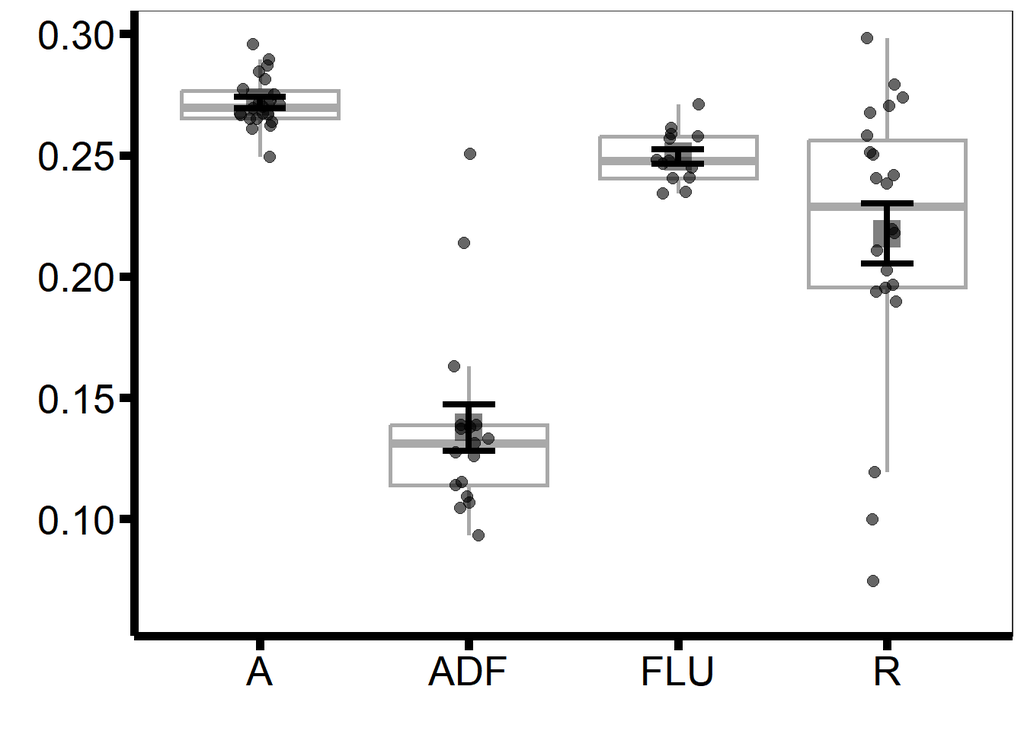

```r
Hexp_plot +
  geom_point(data = Hexp_ci, aes(x = life_history, y = Hexp), shape = 15, size = 6, color="black", fill="black", alpha = 0.5, inherit.aes = FALSE)+
  geom_errorbar(data = Hexp_ci, mapping = aes(x = life_history, y = Hexp, ymin = Hexp - se, ymax = Hexp + se), size = 1.5, color = "black", width = 0.25, inherit.aes = FALSE)
```